# Homework 10

Reed Scott

3/31/2022

# Question 1

*Using a for loop, write a function to calculate the number of zeroes in a numeric vector. Before entering the loop, set up a counter variable counter <- 0. Inside the loop, add 1 to counter each time you have a zero in the matrix. Finally, use return(counter) for the output.*

```r
#Create counter function#
count <- function(x){
  counter <- 0
  for(i in 1:length(x)){
    if(x[i] == 0){
      counter <- counter+1
    }
    else{
      counter <- counter+0
    }
  }
  return(counter)
}

#Create dummy data + run function
rv1 <- rep(0,20)
count(rv1)
```

```
## [1] 20
```

```r
#created a vector of 20 zeros, counter returns 20 zeros
```

I created a function to count every 0. Then I made a mock vector consisting of 20 zeros. When I ran the function on this vector, it returned a count of 20, so I know the function works. Woohoo!

# Question 2

*Use subsetting instead of a loop to rewrite the function as a single line of code.*

```r
#create function
count2 <- function(x){
  return(length(x[which(x == 0)]))
}

#run function
rv2 <- c(rep(0,10),rep(1,10)) #create dataset with 10 zeros
count2(rv2) #returns count of 10
```

```
## [1] 10
```

I created a function that uses subsetting [] and the which() function to select only 0s from the vector. Then I use the length statement in place of a counter to tell us how many zeros there are.

# Question 3

*Write a function that takes as input two integers representing the number of rows and columns in a matrix. The output is a matrix of these dimensions in which each element is the product of the row number x the column number.*

```r
make_matrix <- function(a=4,b=5){
  m <- matrix(nrow = a, ncol = b)
  for(i in 1:nrow(m)){
    for(j in 1:ncol(m)){
      m[i,j] <- i*j
    }
  }
  return(m)
}
make_matrix()
```

```
##      [,1] [,2] [,3] [,4] [,5]
## [1,]    1    2    3    4    5
## [2,]    2    4    6    8   10
## [3,]    3    6    9   12   15
## [4,]    4    8   12   16   20
```

# Question 4

*In the next few lectures, you will learn how to do a randomization test on your data. We will complete some of the steps today to practice calling custom functions within a for loop. Use the code from the March 31st lecture (Randomization Tests) to complete the following steps:* *a.) Simulate a dataset with 3 groups of data, each group drawn from a distribution with a different mean.* *The final data frame should have 1 column for group and 1 column for the response variable.*

```r
groupA <- cbind(rep('groupA',100),rnorm(n = 100, mean = 60, sd = 5))
groupB <- cbind(rep('groupB',100),rnorm(n = 100, mean = 45, sd = 5))
groupC <- cbind(rep('groupC',100),rnorm(n = 100, mean = 81, sd = 5))
df1 <- rbind(groupA,groupB,groupC)
df1
```

```
##        [,1]     [,2]
##   [1,] "groupA" "60.253700615324"
##   [2,] "groupA" "57.7702468986275"
##   [3,] "groupA" "60.5922874458184"
##   [4,] "groupA" "58.2335014350331"
##   [5,] "groupA" "56.9630371113766"
##   [6,] "groupA" "66.7430627306205"
##   [7,] "groupA" "64.7501642281992"
##   [8,] "groupA" "65.5868364067949"
##   [9,] "groupA" "47.3036520658878"
##  [10,] "groupA" "60.6377235037324"
##  [11,] "groupA" "63.8730434750239"
##  [12,] "groupA" "56.5433366583046"
##  [13,] "groupA" "58.4388709914737"
##  [14,] "groupA" "62.1407529790012"
```

[output cut: 286 more lines]

```r
colnames(df1) <- c('group','variable')
df1 <- as.data.frame(df1)
df1$variable <- as.numeric(df1$variable)
```

*b.) Write a custom function that 1) reshuffles the response variable, and 2) calculates the mean of each group in the reshuffled data. Store the means in a vector of length 3.*

```r
library(dplyr)
shuffle <- function(df = df1){
  colnames(df) <- c('group','variable')
  variable <- (sample(df$variable, replace = F))
  group <- df$group
  df2 <- data.frame(group,variable)
  df3 <- df2 %>% group_by(group) %>% summarize(mean = mean(variable))
  return(df3)
}
shuffle(df1)
```

```
## # A tibble: 3 x 2
##   group   mean
##   <chr>  <dbl>
## 1 groupA  61.6
## 2 groupB  61.6
## 3 groupC  62.0
```

*c.) Use a for loop to repeat the function in b 100 times. Store the results in a data frame that has 1 column indicating the replicate number and 1 column for each new group mean, for a total of 4 columns.*

```r
library(tidyverse)
results <- data.frame()
for(i in 1:100){
  df3 <- shuffle(df1)
  df3 <- df3 %>% pivot_wider(names_from = group, values_from = mean)
  #rownames_to_column(df3)
  df3 <-cbind(i,df3)
  results <- rbind(results, df3)
}
results
```

```
##       i   groupA   groupB   groupC
## 1     1 60.57271 62.65417 62.03525
## 2     2 63.60456 61.07764 60.57993
## 3     3 64.60746 61.57030 59.08438
## 4     4 62.94881 60.11078 62.20254
## 5     5 63.76257 59.53625 61.96331
## 6     6 61.98128 61.16206 62.11880
## 7     7 62.52573 62.12671 60.60969
## 8     8 62.55096 59.31268 63.39849
## 9     9 60.37746 61.59642 63.28825
## 10   10 62.37006 62.13160 60.76048
## 11   11 63.30200 62.14144 59.81869
## 12   12 60.23848 62.19740 62.82625
## 13   13 59.97127 63.61077 61.68009
## 14   14 60.84141 63.78658 60.63415
```

[output cut: 86 more lines]

*d.) Use qplot() to create a histogram of the means for each reshuffled group. Or, if you want a challenge, use ggplot() to overlay all 3 histograms in the same figure. How do the distributions of reshuffled means compare to the original means?*

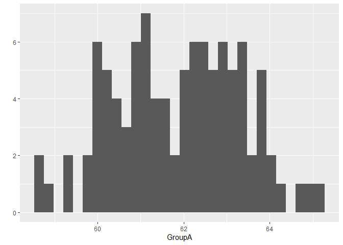

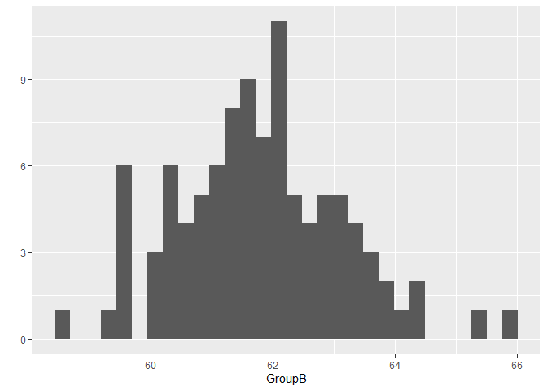

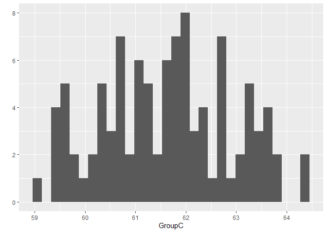

```r
library(ggplot2)
xlabel <- c('GroupA','GroupB','GroupC')
loop.vector <- 2:4
for( i in loop.vector){
  plot <- qplot(results[,i], geom='histogram',xlab = xlabel[i-1])
  print(plot)
}
```